# Introducción al análisis de datos en R

# Flujo típico de un proyecto

[interactive chart not shown]

Flujo simple de un proyecto

# Nuestro primer (mini)proyecto

Sabemos que en Colombia la inflación se ha acelerado, sin embargo, no en todas las ciudades se ha comportado de la misma manera.

**1. Pregunta** ¿Cómo ha diferido el comportamiento de la inflación anual entre ciudades del Caribe y el centro?

Para responder esta pregunta procederémos de la siguiente manera

- Paso 1: Conseguir los datos relevantes. En este caso, el IPC por ciudades calculado por el [DANE](https://www.dane.gov.co/index.php/estadisticas-por-tema/precios-y-costos/indice-de-precios-al-consumidor-ipc/ipc-actualizacion-metodologica-2019)
- Paso 1: Elegir 3 ciudades
- Paso 2: Calcular la inflación anual
- Paso 3: Decidir como comunicamos nuestro hallazgo. En este caso, haremos una gráfica

**2. Datos** Usamos el Índice de Precios al Consumidor, IPC, calculado mensualmente por el DANE. En el Repositorio del curso puede descargar los datos [IPC](https://github.com/caribe-en-datos/viernes_code/blob/main/data/ipc.xls)

En esta fase debemos limpiar y organizar los datos para poder realizar el análisis. Esta parte es muy importante, a veces no es tan emocionante, pero es imprescindible. Como en todo modelo, Si entra basura sale basura.

```r
library(readxl)
ipc <- read_excel("C:/Users/andresmv/OneDrive - Universidad del Norte/Drive/Uninorte/Uninorte-docencia/Data analytics/viernes_code/viernes_code/data/ipc.xls")
head(ipc)
```

```
# A tibble: 6 x 4
  year  ciudad         ipc   mes
  <chr> <chr>        <dbl> <dbl>
1 2018  MEDELLÍN      97.0     1
2 2018  BARRANQUILLA  97.3     1
3 2018  IBAGUÉ        97.9     1
4 2018  SINCELEJO     97.2     1
5 2018  BUCARAMANGA   98.2     1
6 2018  PEREIRA       97.7     1
```

es un lenguaje orientado a objetos. En nuestro casso, el objeto *ipc* que observamos en la ventana *Environment* es del tipo dataframe. Es ecir, una arreglo matricial de datos, donde en cada fila tenemos las observaciones y en cada columna las variables.

```r
class(ipc)
```

```
[1] "tbl_df"     "tbl"        "data.frame"
```

- Paso 2: elegir 3 ciudades.

```r
library(dplyr)
ipcs<-filter(ipc,ciudad=="BARRANQUILLA" | ciudad=="BOGOTÁ, D.C." | ciudad=="CALI")
```

- Paso 3: Crear variables

En la base de datos tenemos una columna que identifica el año y otra que identifica el mes. Necesitamos tener una nueva columna que tenga la fecha completa

```r
library(lubridate)
ipcs$dia<-1
ipcs<-mutate(ipcs,date=make_date(year,mes,dia))
```

**3. “Algoritmo”**

Recuerde que la inflación se computa como la variación porcentual de IPC, y en este caso la variación se toma comparando el mes de un año con el mismo mes del año anterior. Así, por ejemplo, la inflación anual de agosto 2002 sería

$$Inflación_{ag22}=\dfrac{ipc_{ag22}}{ipc_{ago21}}-1$$

Para ilustrar, hagamos el cálculo únicamente para la ciudad de Barranquilla

```r
baq<-filter(ipcs,ciudad=="BARRANQUILLA")
baq<-mutate(baq,inf=(ipc/lag(ipc,n=12L))-1)
```

El cálculo lo debemos hacer para cada ciudad. Teniendo en cuenta que nuestros datos están estructurados en formato largo (las ciudades son categorías de la variable *ciudad*). Para ello, ampliaremos el código anterior con la función *group_by*

```r
ipcs<-ipcs%>%group_by(ciudad)%>%mutate(inf=(ipc/lag(ipc,n=12L))-1)
```

**4. Comunicación**

Vamos a comunicar nuestro resultado usando una gráfica de lineas que muestre la evolución temporal de la inflación para cada ciudad. Usaremos la biblioteca *ggplot2* para graficar. Primero ilustramos con el gráfico únicamente para la ciudad de Barranquilla

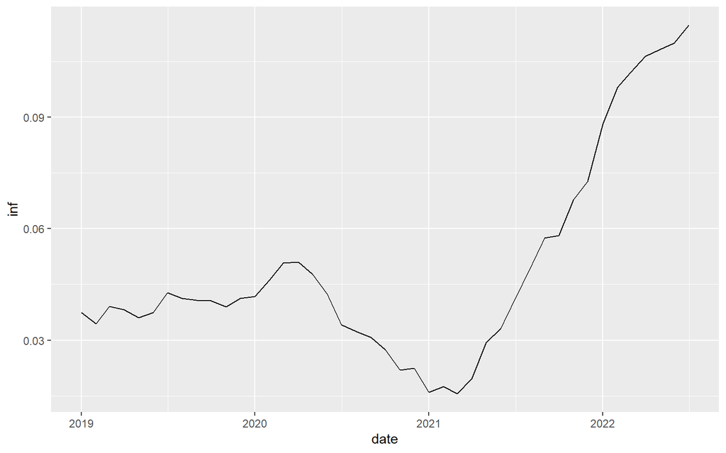

```r
library(ggplot2)
baq<-na.omit(baq)
baq.plot<-ggplot(baq,aes(x=date,y=inf))+geom_line()
baq.plot
```

El gráfico con las 3 ciudades lo construimos de la siguiente manera

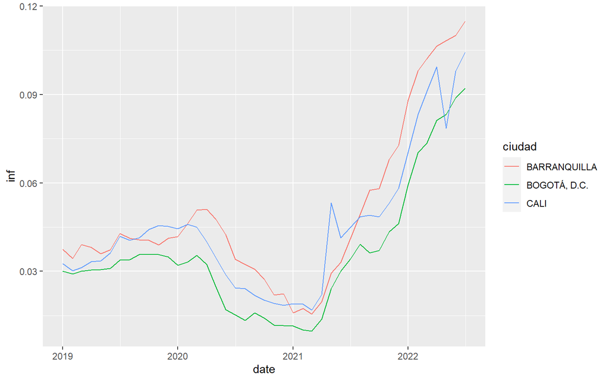

```r
ipcs<-na.omit(ipcs)
ggplot(ipcs,aes(x=date,y=inf,colour=ciudad))+geom_line()
```

La presentación del gráfico la podemos mejorar, pero eso será tema de otra sesión